# Final Project for BIOS 26813

Author

Luke Friedman, Data Stored Online via: https://raw.githubusercontent.com/lukekfriedman/PolypterusBoneDensity/refs/heads/main/consolidated_bone_density_data.csv

## Biological Background

This project will focus on one metric (bone density) of the skeletal features in Polypterus to begin to address the overall question of whether phenotypes between aquatically-raised versus terrestrially-raised individuals are significantly different. This bone density data was collected for five different skeletal elements of Polypterus fin rays: Propterygia, metapterygia, radials, proximal fin rays (hemitrichia), and distal fin rays (hemitrichia). Organization of this data, described below, allows for preliminary analysis through bone density of the following questions: 1. Is overall bone density significantly different individuals raised aquatically versus terrestrially (overall and within specific bone groups)? 2. Is there significant difference in bone density between anterior (ventral) and posterior (dorsal) bone elements (overall and between treatments)? 3. Is there a significant difference in bone density between proximal versus distal bone elements (overall, between treatments, and within fin rays)?

As more bone density data remains to be collected for this thesis, this project will provide a preliminary basis for further analysis on bone density analysis. Further, looking forward, several other points of analysis will be included in evaluating phenotypic plasticity in Polypterus overall. Since the pectoral fins of terrestrial Polypterus are high load-bearing points of contact on the surface medium, the physical character between terrestrial and aquatic individuals may differ. Other studies have made compelling links from physical characteristics (flexural capacity) to mechanical capacity of other fish fins (Sahil et al. 2018, Das 2023); The flexural modulus of Polypterus pectoral fins will be compared between terrestrial and aquatic groups later in this thesis’s progression as a proxy of phenotypic plasticity. Further, the morphologies and geometries of pectoral fin rays in aquatically mobile versus benthic taxa have been shown to demonstrate significant differences (Taft 2011), and within benthic species dorsal/ventral positioning of fin rays creates significant morphological variation due to difference in substrate interaction (Taft & Taft 2012), inviting additional anaylsis of plasticity in Polypterus fin geometries and morphologies. similar to what has been seen in their clavicals in particular (Standen et al. 2014).

Differences in these measurements between these two groups might indicate that phenotypic plasticity in pectoral fins may have allowed for improved ability for terrestrial locomotion and innovation in amphibious fish during the terrestrial invasion. To begin, this project will utilize the data currently available on bone density to begin to evaluate this comparison.

## The Data

The data set used in this project covers the bone density data for 10 individual specimens: five raised aquatically (essentially as a ‘normal’ fish in a fish tank), and five raised terrestrially (mostly on dirt with a couple of shallow ponds). For each individual specimen the propterygia, metapterygia, radials, proximal fin rays, and distal fin rays were measured. For the propterygia, metapterygia, radials, and proximal fin rays, five bone density measurements were taken around the mid-length of each bone. There were usually fourteen radials, although sometimes thirteen and fifteen were observed. For each individual, five anterior and five posterior rays were measured (at mid-length, five measurements each). The same five anterior and posterior rays were measured for distal fin rays, although, instead of five measurements at mid-length, five measurements were taken across the proximal-distal axis, starting immediately after the first joint in each ray, and extending towards the termination of the ray, capturing the bone density trends radiating distally and outwards from jointing with the radials.

```
[1]  5905.556  6761.244  7520.042  8873.309 11106.225
                       [,1]      [,2]      [,3]      [,4]       [,5]
Intensity Measured 5905.556 6761.2442 7520.0418 8873.3088 11106.2246
HA Vals             -20.379  101.8616  212.4351  417.3955   789.2673
```

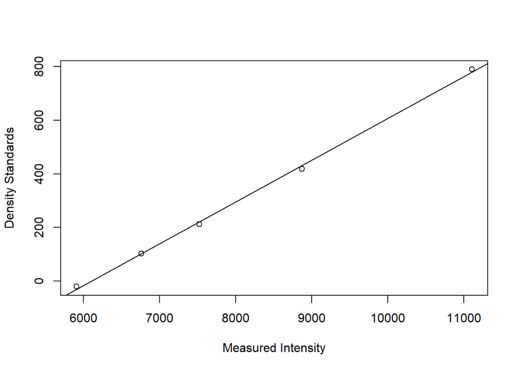

```
Call:
lm(formula = ex_var ~ means)

Residuals:
        1         2         3         4         5
 11.14913   0.01496  -7.68413 -13.65534  10.17538

Coefficients:
              Estimate Std. Error t value Pr(>|t|)
(Intercept) -9.520e+02  2.543e+01  -37.44 4.19e-05 ***
means        1.559e-01  3.087e-03   50.49 1.71e-05 ***
---
Signif. codes:  0 '***' 0.001 '**' 0.01 '*' 0.05 '.' 0.1 ' ' 1

Residual standard error: 12.56 on 3 degrees of freedom
Multiple R-squared:  0.9988,    Adjusted R-squared:  0.9984
F-statistic:  2549 on 1 and 3 DF,  p-value: 1.711e-05
```

```r
regressionHAS <- function(file_path) {

  d1 <- read.csv(file_path, header = TRUE)
  colnames(d1) <- c('group', 'values')
  d1$values <- as.numeric(d1$values)
  n_group <- nrow(d1) %/% 5

  means <- sapply(1:n_group, function(i) {mean(d1$values[((i-1)*5+1):(i*5)])})
  print(means)

  ex_var <- c(-20.379, 101.8616, 212.4351, 417.3955, 789.2673)
  matrix <- matrix(c(means, ex_var), nrow=2, byrow=TRUE)

rownames(matrix) <- c("Intensity Measured", "HA Vals")
print(matrix)

plot(means, ex_var, ylab="Density Standards", xlab="Measured Intensity")
mod <- lm(ex_var ~ means)
abline(mod)
print(summary(mod))
}
lm1 <- regressionHAS("C:/Users/Luke Friedman/Documents/Polypterus/B5/HASB5.csv")
```

```r
lm1
```

```
Call:
lm(formula = ex_var ~ means)

Residuals:
        1         2         3         4         5
 11.14913   0.01496  -7.68413 -13.65534  10.17538

Coefficients:
              Estimate Std. Error t value Pr(>|t|)
(Intercept) -9.520e+02  2.543e+01  -37.44 4.19e-05 ***
means        1.559e-01  3.087e-03   50.49 1.71e-05 ***
---
Signif. codes:  0 '***' 0.001 '**' 0.01 '*' 0.05 '.' 0.1 ' ' 1

Residual standard error: 12.56 on 3 degrees of freedom
Multiple R-squared:  0.9988,    Adjusted R-squared:  0.9984
F-statistic:  2549 on 1 and 3 DF,  p-value: 1.711e-05
```

```r
cf <- coef(lm1)
Intercept1 <- cf[1]
Slope1 <- cf[2]

intenseregression <- function(incsv, outcsv, m, b) {


  ndata <- read.csv(incsv, header = TRUE)


  ndata$y <- m * ndata$x + b


  write.csv(ndata, outcsv, row.names = FALSE)


  print(paste("New data:", outcsv))
}


intenseregression(
  incsv = "C:/Users/Luke Friedman/Documents/Polypterus/B5/B5proxrays.csv",
  outcsv = "B5proxraysnew.csv",
  m = Slope1,
  b = Intercept1
)
```

```
[1] "New data: B5proxraysnew.csv"
```

```r
A2.1densities <- read.csv('B5proxraysnew.csv')
View(A2.1densities)
write.csv(A2.1densities,"~/Polypterus/B5/B5proxraysnew.csv", row.names = FALSE)
```

This calibrated bone density data would be produced as a single column csv file for a specific bone element, with important dorsal/ventral and proximal/distal positioning information held within the single column of the variable ‘Bone Density’ for each file. For example, all radial files were measured from dorsal-most to ventral-most, so in an individual with fourteen radials measured five times each, the first five rows of the column represent the first most dorsal radial, and the last five rows represent the most ventral radial for a total of seventy rows. All individual csv files, then, had to be aggregated into a single data set covering the measurements for all ten individuals. The code for this data conglomeration is shown below. Within the data set, the variables Specimen (denoting the specific individual), Treatment (aquatic vs. terrestrial), Bone.Group (radials, proximal radials, etc.), Position (Dorsal vs Ventral, Proximal vs Distal), and BoneDensity (mg/ccm) are listed.

DATA SET HEADER

```r
data <- read.csv("https://raw.githubusercontent.com/lukekfriedman/PolypterusBoneDensity/refs/heads/main/consolidated_bone_density_data.csv")
head(data)
```

```
  Specimen.ID Treatment.Group Bone.Group BoneDensity Position
1          A2         Aquatic    Radials    572.8262  Dorsal1
2          A2         Aquatic    Radials    637.7440  Dorsal1
3          A2         Aquatic    Radials    694.1515  Dorsal1
4          A2         Aquatic    Radials    666.4417  Dorsal1
5          A2         Aquatic    Radials    596.0085  Dorsal1
6          A2         Aquatic    Radials    790.7494  Dorsal2
```

Aggregation of the code from individual specimen and bone group csv files used the following code, which organized files by bone groups (from the file names) before putting them through a function which categorizes any given input file by Specimen.ID, Treatment Group, and Bone Group (along with associated densities), and collects it into a single csv file using rbind:

```r
path_to_data <- "C:/Users/Luke Friedman/Documents/Polypterus"

specimen_ids <- list( Aquatic = c("A2", "A3", "B4", "B5", "C2"), Terrestrial = c("bluered", "gror", "orgwht", "redblue", "redred"))

# Bone groups
bone_groups <- list(
  Radials = list(filename_suffix = "Radials.csv"),

  Proximal_Fin_Rays = list(filename_suffix = "proxrays.csv"),
  Distal_Fin_Rays = list(filename_suffix = "distrays.csv"),
  Prop_Metap = list(filename_suffix = "PrMt.csv")
)

process_csv <- function(file_path, bone_group, specimen_id, treatment_group = list()) {
  data <- read.csv(file_path)

  if ("Density" %in% colnames(data)) {
    bone_density <- data[["Density"]]
  } else {
    bone_density <- data[[3]]
  }

  if (is.null(bone_density) || length(bone_density) == 0) {
    warning(paste("No valid bone density data found in file:", file_path))
    return(NULL)
  }

  processed_data <- data.frame(
    Specimen.ID = specimen_id,
    Treatment.Group = treatment_group,
    Bone.Group = bone_group,
    BoneDensity = bone_density
  )

  return(processed_data)
}


all_data <- data.frame()
for (treatment in names(specimen_ids)) {
  for (specimen in specimen_ids[[treatment]]) {
    for (bone_group in names(bone_groups)) {
      file_path <- file.path(path_to_data, paste0(specimen, "_", bone_groups[[bone_group]]$filename_suffix))

      if (!file.exists(file_path)) {
        warning(paste("File not found:", file_path)) }

        bone_data <- process_csv(
          file_path = file_path,
          bone_group = bone_group,
          specimen_id = specimen,
          treatment_group = treatment
        )
          all_data <- rbind(all_data, bone_data)}}}

output_file_path <- file.path(path_to_data, "consolidated_bone_density_data1.csv")
write.csv(all_data, file = output_file_path, row.names = FALSE)
cat("Final data saved to:", output_file_path, "\n")
```

```
Final data saved to: C:/Users/Luke Friedman/Documents/Polypterus/consolidated_bone_density_data1.csv
```

## Methods

As described above, the first overarching question for this data was, “Is overall bone density significantly different individuals raised aquatically versus terrestrially (overall and within specific bone groups)?”.

Before answering this question the data was visualized to understand its distribution using the code below. As seen in the first histogram and density plot. The raw data shows a massive range of bone density values, from <300 mg/ccm to over 20,000 mg/ccm. This is not only unexpected for bone densities in the fins of fish of the same species, but is almost certainly the result of some measurement error. To better understand the source of these unexpected bone density values, the density plot was log-transformed, revealing a relatively strong division of two main density groups which create the bimodal distribution seen below. To find the source of this second high-value group, the data was first divided into bone group with the logic that perhaps a certain bone group demonstrated a particularly high bone density compared to the rest. This was not the case as shown by the retained bimodal distribution in the faceted density plots. Similarly, dividing the data into dorsal versus ventral positioning resulted in continued bimodal distributions, again suggesting that this positioning was not the source of the extreme values.

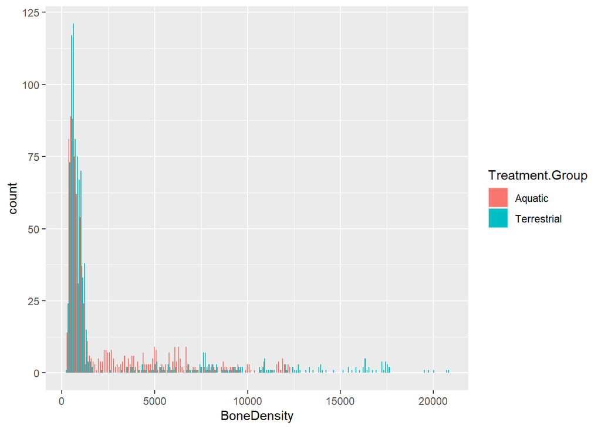

```r
library(tidyverse)



hist1 <- data[data$Treatment.Group %in% c("Aquatic", "Terrestrial"),]

ggplot(data = hist1, aes(x = BoneDensity, fill = Treatment.Group)) + geom_histogram(position = "dodge", binwidth = 100)
```

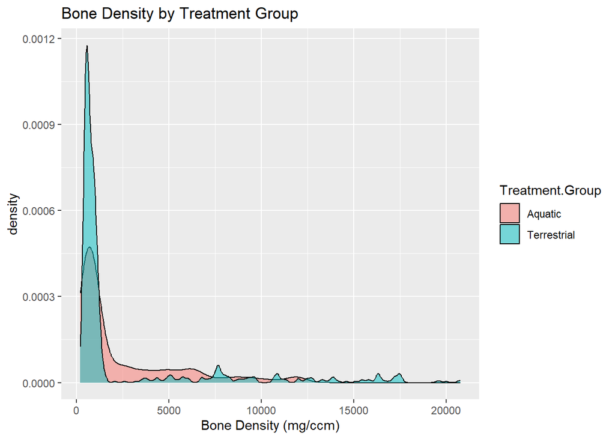

```r
ggplot(data=hist1, aes(x=BoneDensity, fill=Treatment.Group)) + geom_density(alpha=0.5) + labs(title="Bone Density by Treatment Group", x="Bone Density (mg/ccm)")
```

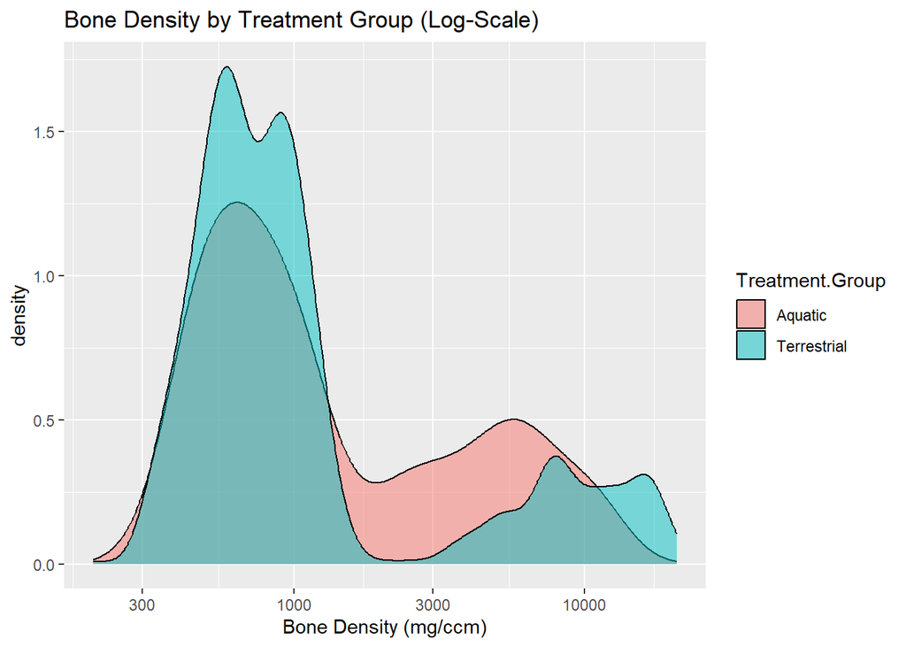

```r
ggplot(data=hist1, aes(x=BoneDensity, fill=Treatment.Group)) + geom_density(alpha=0.5) + scale_x_log10() + labs(title="Bone Density by Treatment Group (Log-Scale)", x="Bone Density (mg/ccm)")
```

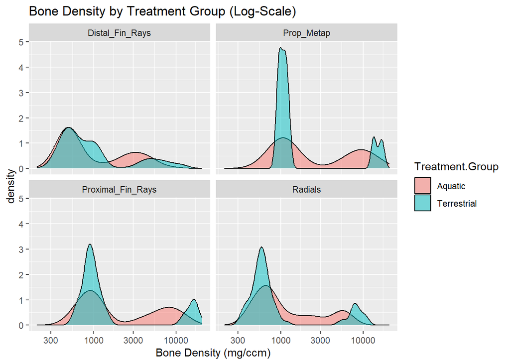

```r
ggplot(data=hist1, aes(x=BoneDensity, fill=Treatment.Group)) + geom_density(alpha=0.5) + scale_x_log10() + labs(title="Bone Density by Treatment Group (Log-Scale)", x="Bone Density (mg/ccm)") + facet_wrap(~Bone.Group)
```

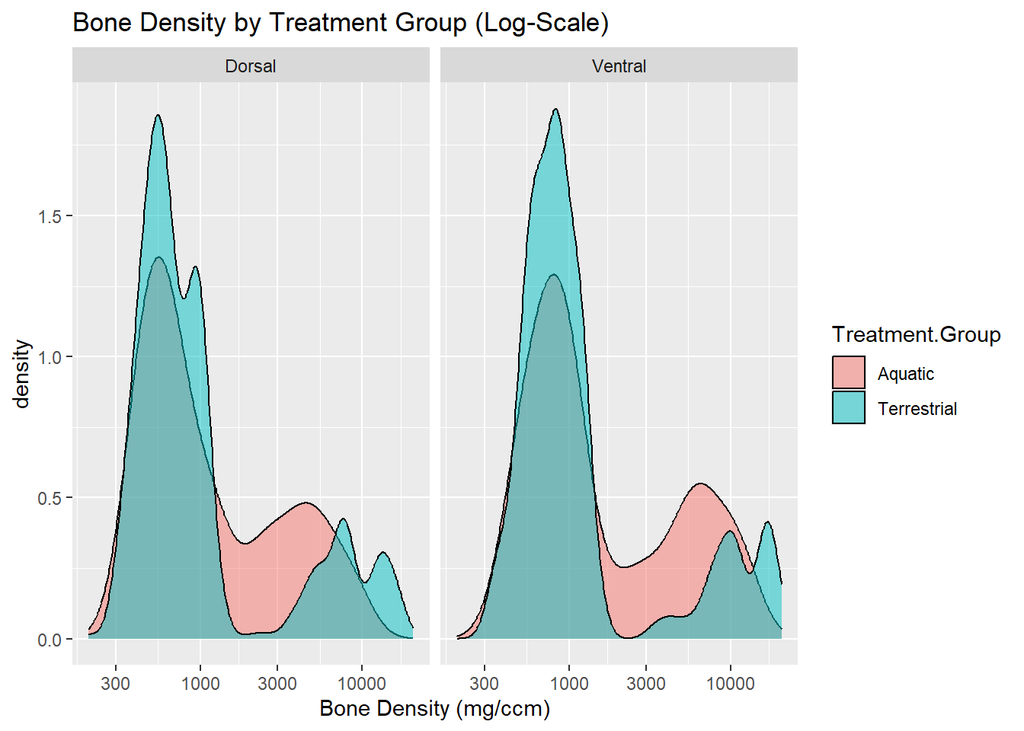

```r
library(stringr)

dorven <- hist1 %>%
  mutate(Position_Group = case_when(
    str_detect(Position, regex("Dorsal|Proximal1|Proximal2|Proximal3|Proximal4|Proximal5|Distal1|Distal2|Distal3|Distal4|Distal5|Mid1|Mid2|Mid3|Mid4|Mid5|propterygium")) ~ "Dorsal",
    str_detect(Position, regex("Ventral|Proximal6|Proximal7|Proximal8|Proximal9|Proximal10|Distal6|Distal7|Distal8|Distal9|Distal10|Mid6|Mid7|Mid8|Mid9|Mid10|metapterygium")) ~ "Ventral",
    TRUE ~ "Other"
  ))

ggplot(data=dorven, aes(x=BoneDensity, fill=Treatment.Group)) + geom_density(alpha=0.5) + scale_x_log10() + labs(title="Bone Density by Treatment Group (Log-Scale)", x="Bone Density (mg/ccm)") + facet_wrap(~Position_Group)
```

The next potential source of these deviant values was thought to be from particular individuals. Dividing the data into specific individual density distributions revealed that three particular individuals (“bluered”, “B4”, and “C2”) show distributions with general values far higher than the rest of the sampled individuals. This was confirmed and better visualized by producing mean and standard deviation plots for each individual.

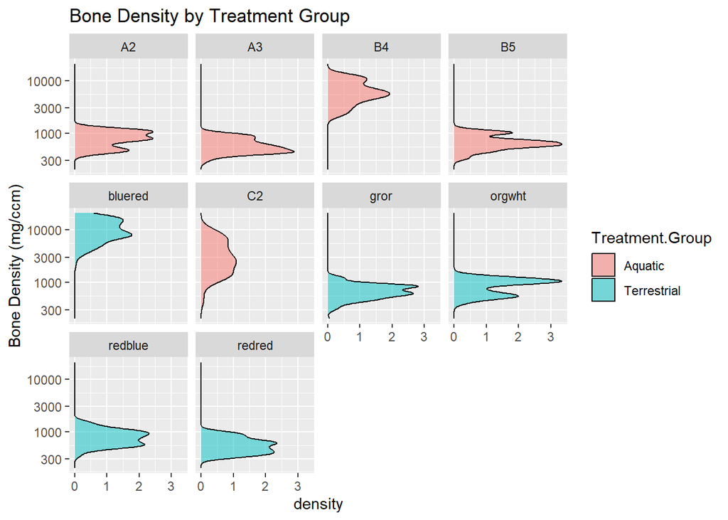

```r
ggplot(data=hist1, aes(x=BoneDensity, fill=Treatment.Group)) + geom_density(alpha=0.5) + scale_x_log10() + labs(title="Bone Density by Treatment Group", x="Bone Density (mg/ccm)") +facet_wrap(~Specimen.ID) + coord_flip()
```

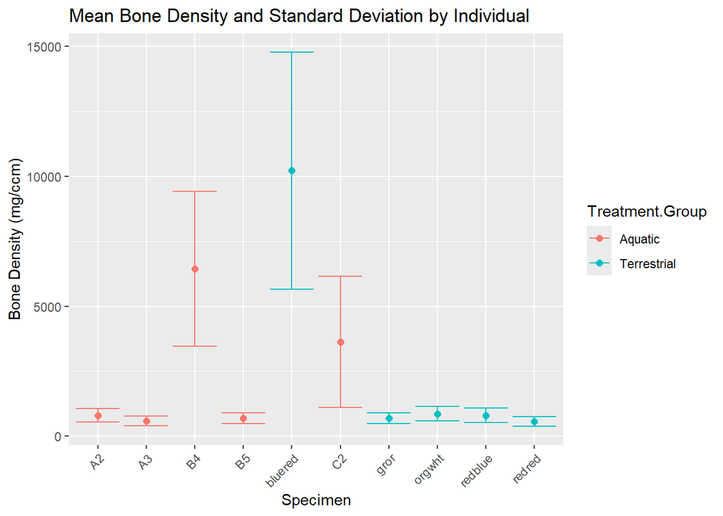

```r
static <- data %>% group_by(Treatment.Group, Specimen.ID) %>% summarise(meandensity=mean(BoneDensity), SDdensity=sd(BoneDensity))
ggplot(static, aes(x=Specimen.ID, y=meandensity, color=Treatment.Group)) + geom_point(size=2)+ geom_errorbar(aes(ymin=meandensity-SDdensity, ymax=meandensity+SDdensity)) + labs(title = "Mean Bone Density and Standard Deviation by Individual", x = "Specimen", y = "Bone Density (mg/ccm)") + theme(axis.text.x = element_text(angle = 45, hjust = 1))
```

This presented reason to observe data with these three extreme individuals removed to represent data which is actually representative of true bone density values. This filtered data set produces a somewhat normal distribution when log transformed as shown in the density plots as well as the Q-Q plot shown below, and the same mean and standard deviation plot as used above shows a much more reasonable distribution of means across individuals.

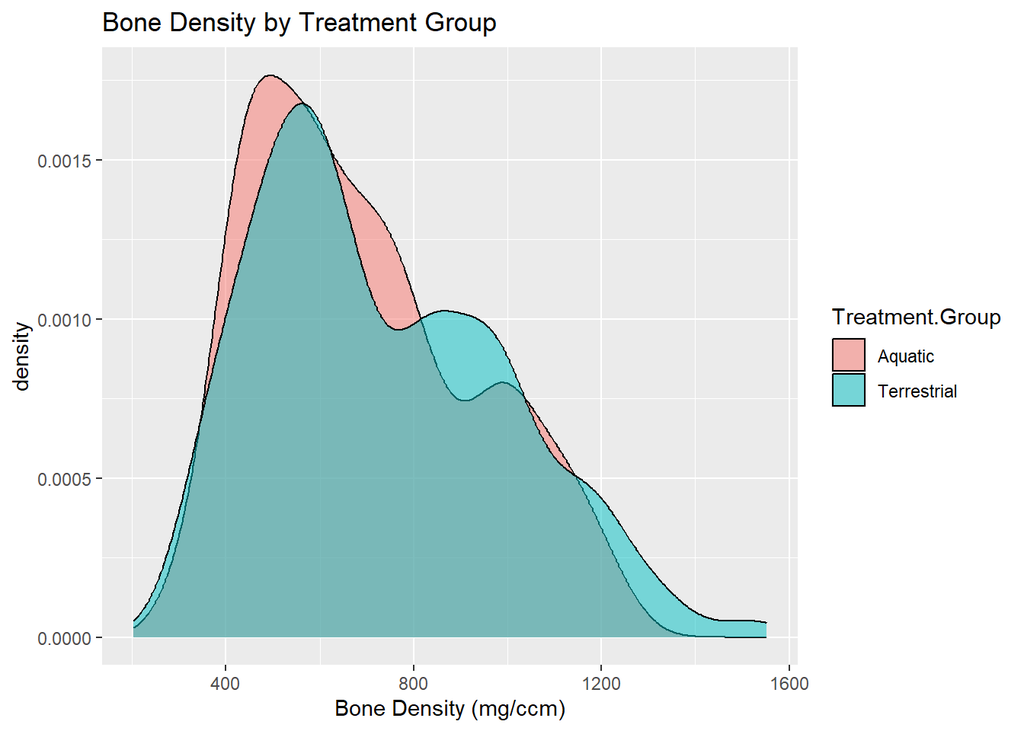

```r
filtdata <- data %>% filter(!Specimen.ID %in% c("bluered", "C2", "B4"))

hist2 <- filtdata[filtdata$Treatment.Group %in% c("Aquatic", "Terrestrial"),]

ggplot(data=hist2, aes(x=BoneDensity, fill=Treatment.Group)) + geom_density(alpha=0.5) + labs(title="Bone Density by Treatment Group", x="Bone Density (mg/ccm)") #+ xlim(0, 2000)
```

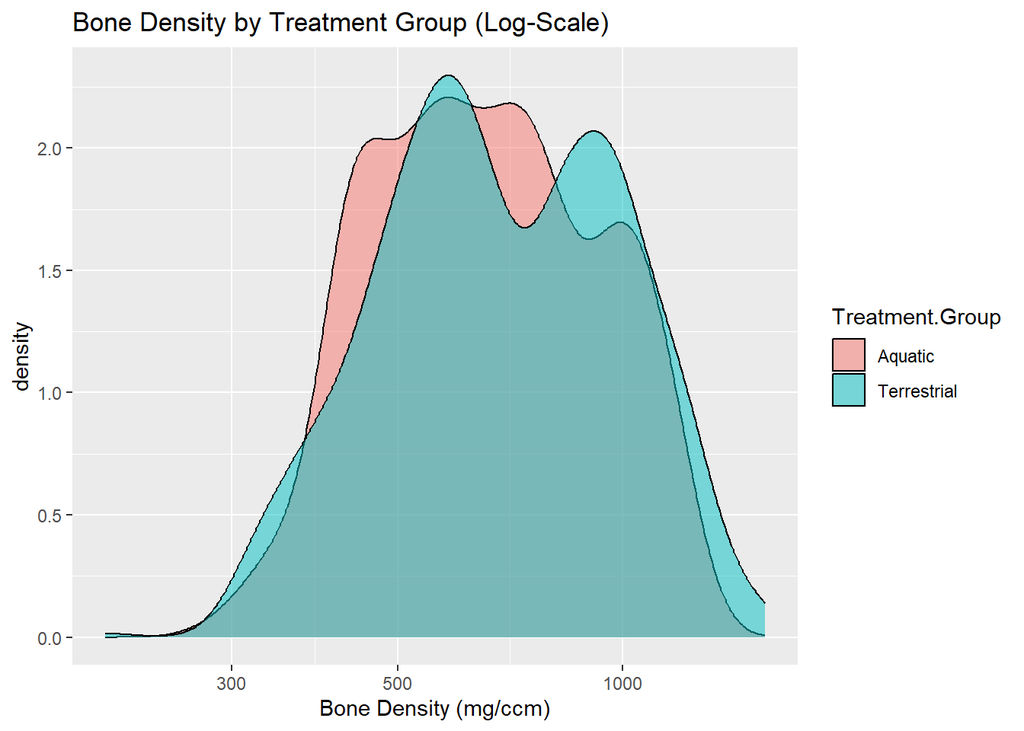

```r
ggplot(data=hist2, aes(x=BoneDensity, fill=Treatment.Group)) + geom_density(alpha=0.5) + scale_x_log10() + labs(title="Bone Density by Treatment Group (Log-Scale)", x="Bone Density (mg/ccm)")
```

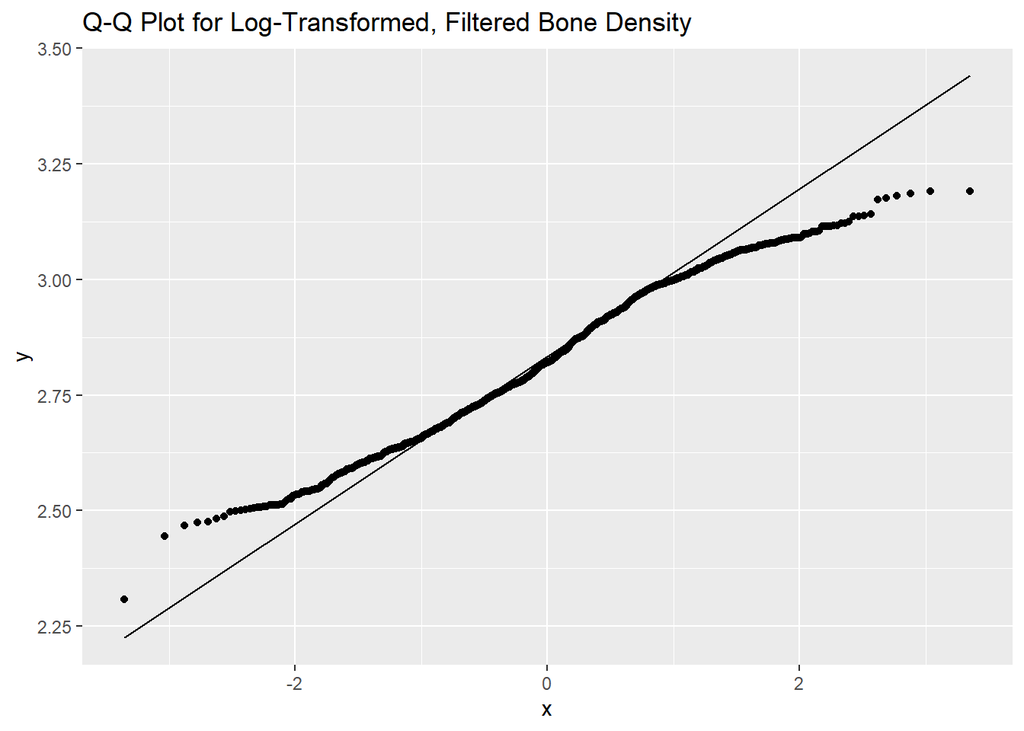

```r
filtdata2 <- data %>% filter(!Specimen.ID %in% c("bluered", "C2", "B4")) %>% mutate(BoneDensity=log10(BoneDensity))

ggplot(filtdata2, aes(sample = BoneDensity)) +
  stat_qq(distribution = qnorm)+
  stat_qq_line(distribution = qnorm)+
  labs(title="Q-Q Plot for Log-Transformed, Filtered Bone Density")
```

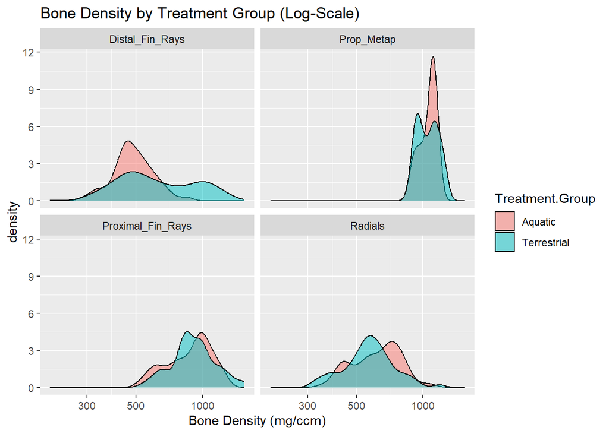

```r
ggplot(data=hist2, aes(x=BoneDensity, fill=Treatment.Group)) + geom_density(alpha=0.5)+ scale_x_log10() + labs(title="Bone Density by Treatment Group (Log-Scale)", x="Bone Density (mg/ccm)") + facet_wrap(~Bone.Group)
```

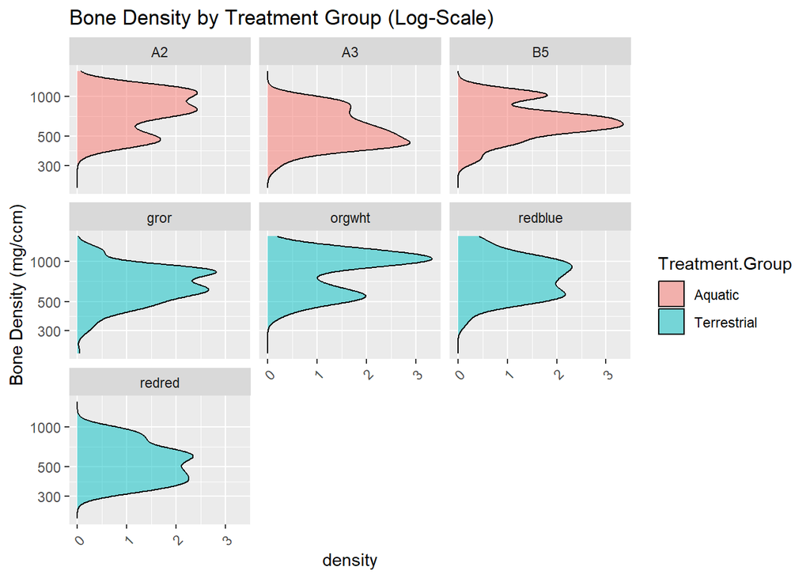

```r
ggplot(data=hist2, aes(x=BoneDensity, fill=Treatment.Group)) + geom_density(alpha=0.5)+ scale_x_log10()  + labs(title="Bone Density by Treatment Group (Log-Scale)", x="Bone Density (mg/ccm)") +facet_wrap(~Specimen.ID) + coord_flip()+theme(axis.text.x = element_text(angle = 45, hjust = 1))
```

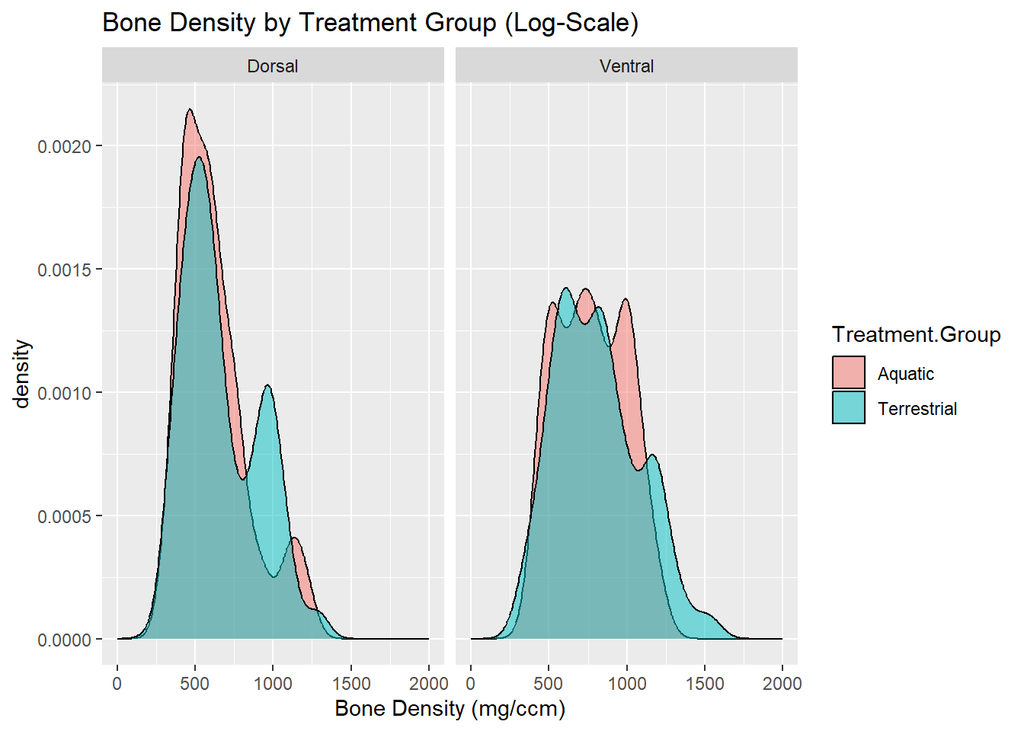

```r
dorven2 <- hist2 %>%
  mutate(Position_Group = case_when(
    str_detect(Position, regex("Dorsal|Proximal1|Proximal2|Proximal3|Proximal4|Proximal5|Distal1|Distal2|Distal3|Distal4|Distal5|Mid1|Mid2|Mid3|Mid4|Mid5|propterygium")) ~ "Dorsal",
    str_detect(Position, regex("Ventral|Proximal6|Proximal7|Proximal8|Proximal9|Proximal10|Distal6|Distal7|Distal8|Distal9|Distal10|Mid6|Mid7|Mid8|Mid9|Mid10|metapterygium")) ~ "Ventral",
    TRUE ~ "Other"
  ))

ggplot(data=dorven2, aes(x=BoneDensity, fill=Treatment.Group)) + geom_density(alpha=0.5)+ scale_x_log10()  + labs(title="Bone Density by Treatment Group (Log-Scale)", x="Bone Density (mg/ccm)") + facet_wrap(~Position_Group) + xlim(0,2000)
```

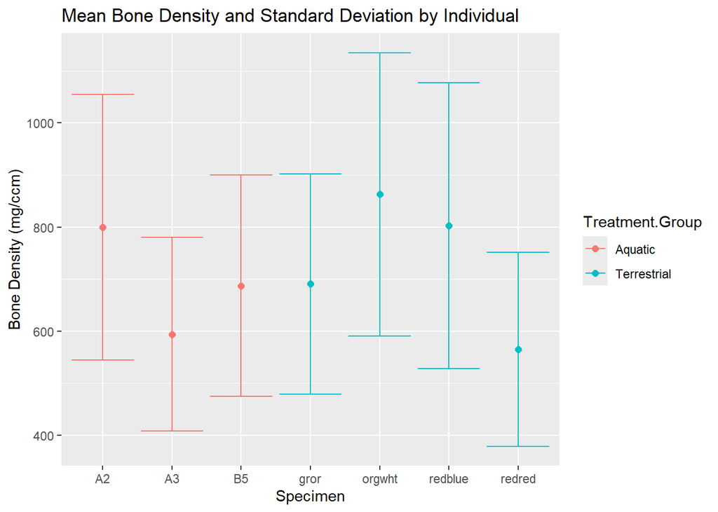

```r
static2 <- filtdata %>% group_by(Treatment.Group, Specimen.ID) %>% summarise(meandensity=mean(BoneDensity), SDdensity=sd(BoneDensity))
ggplot(static2, aes(x=Specimen.ID, y=meandensity, color=Treatment.Group)) + geom_point(size=2)+ geom_errorbar(aes(ymin=meandensity-SDdensity, ymax=meandensity+SDdensity)) + labs(title = "Mean Bone Density and Standard Deviation by Individual", x = "Specimen", y = "Bone Density (mg/ccm)")
```

## Results

Taking this somewhat-normally distributed data, analysis of the questions outlined above was done, using both the filtered (excluding the three outlying individuals) as well as the unfiltered (including the three outlying) data to maintain consistency in case later analysis shows that somehow the data of these three individuals is in fact accurate. To begin to analyze the overall bone density between treatments overall and within different bone groups, a standard t test was applied to both the unfiltered and filtered data sets, visualized by the error plots shown below (note the different y axis values between the two). As shown, the difference in overall bone density across bone groups between the two treatments (aquatic versus terrestrial) is insignificant in the unfiltered data containing the outlying individuals (p-value=0.3606), while the difference between treatments overall in filtered data is significant (p-value=0.006643). Testing for the robustness of these results through bootstrap re–sampling with replacement demonstrates the robustness of this result without bonferroni correction as visualized in the histograms below for 1000 replications with resampling. With bonferroni correction no p-values out of 1000 show significance in unfiltered data, while only 88 (8.8%) show significance in filtered data. This does imply that there is some significance in the difference in treatment values post-adjustment, although the effect might be more modest than is initially presented in the histograms.

Overall, these results imply a relatively robust relationship between treatment group and overall bone density in filtered data, although the bonferroni adjustment results suggests caution in assigning high strength to this relationship overall. Regardless, there is indication that overall bone densities in the fins of individuals between aquatic and terrestrial treatments might experience a difference in bone density across the bone groups within the fin itself. However, this may be impacted by a particular bone group more so than others.

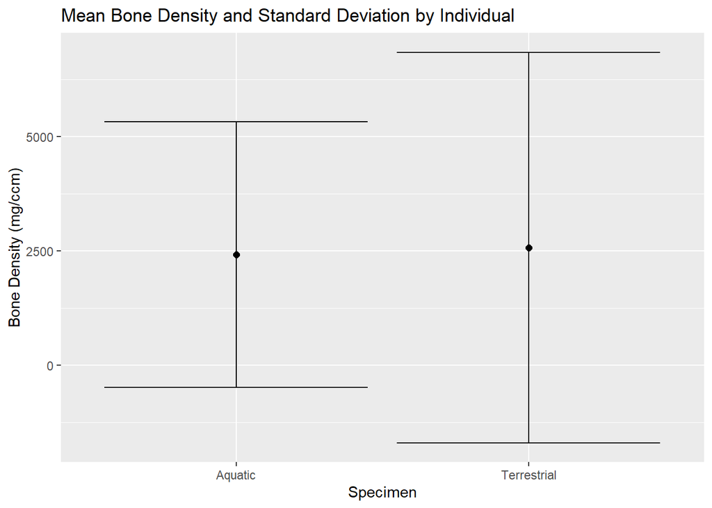

```r
static3 <- data %>% group_by(Treatment.Group) %>% summarise(meandensity=mean(BoneDensity), SDdensity=sd(BoneDensity))

ggplot(static3, aes(x=Treatment.Group, y=meandensity)) + geom_point(size=2)+ geom_errorbar(aes(ymin=meandensity-SDdensity, ymax=meandensity+SDdensity)) + labs(title = "Mean Bone Density and Standard Deviation by Individual", x = "Specimen", y = "Bone Density (mg/ccm)")
```

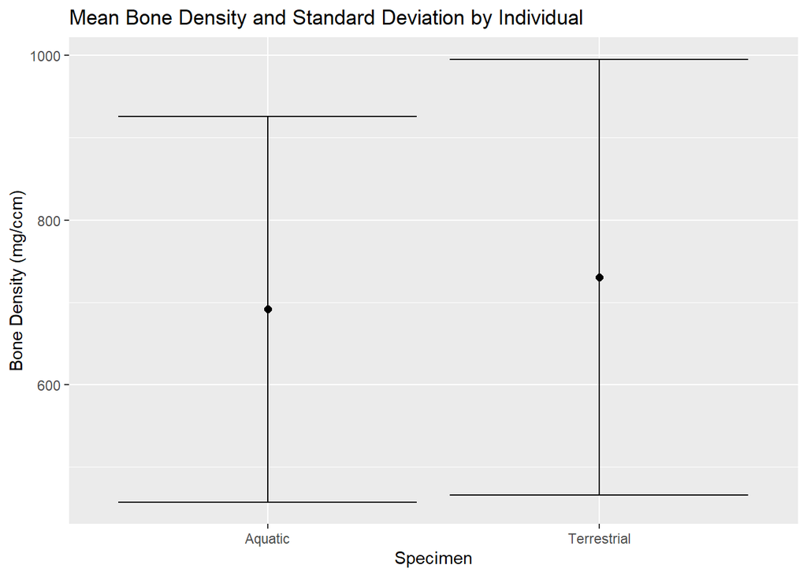

```r
static4 <- filtdata %>% group_by(Treatment.Group) %>% summarise(meandensity=mean(BoneDensity), SDdensity=sd(BoneDensity))

ggplot(static4, aes(x=Treatment.Group, y=meandensity)) + geom_point(size=2)+ geom_errorbar(aes(ymin=meandensity-SDdensity, ymax=meandensity+SDdensity)) + labs(title = "Mean Bone Density and Standard Deviation by Individual", x = "Specimen", y = "Bone Density (mg/ccm)")
```

```r
ttestoverall1 <- t.test(BoneDensity ~ Treatment.Group, data=hist1, var.equal=TRUE)
print(ttestoverall1)
```

```
    Two Sample t-test

data:  BoneDensity by Treatment.Group
t = -0.91443, df = 1778, p-value = 0.3606
alternative hypothesis: true difference in means between group Aquatic and group Terrestrial is not equal to 0
95 percent confidence interval:
 -498.5387  181.4863
sample estimates:
    mean in group Aquatic mean in group Terrestrial
                 2417.238                  2575.765
```

```r
ttestoverall2 <- t.test(BoneDensity ~ Treatment.Group, data=hist2, var.equal=TRUE)
print(ttestoverall2)
```

```
    Two Sample t-test

data:  BoneDensity by Treatment.Group
t = -2.7188, df = 1258, p-value = 0.006643
alternative hypothesis: true difference in means between group Aquatic and group Terrestrial is not equal to 0
95 percent confidence interval:
 -67.24371 -10.87424
sample estimates:
    mean in group Aquatic mean in group Terrestrial
                  691.613                   730.672
```

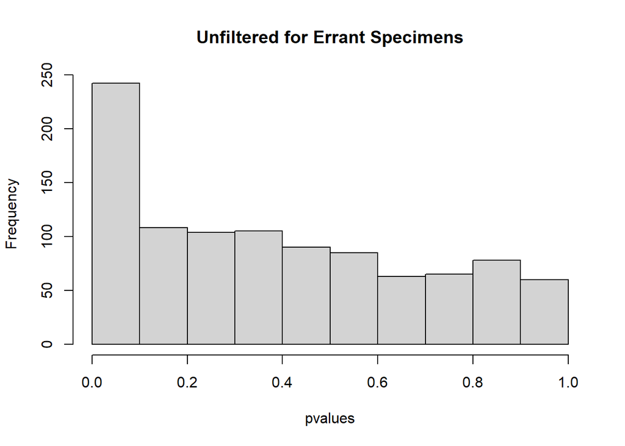

```r
get_p_value_t_test <- function() {
  resamp <- hist1 %>% sample_frac(1, replace = TRUE)
  tresults <- t.test(BoneDensity ~ Treatment.Group, data = resamp, var.equal = TRUE)
  return(tresults$p.value)
}
set.seed(123)
pvalues <- replicate(n = 1000, expr=get_p_value_t_test())
sig <- sum(pvalues < 0.05)
hist(pvalues, main="Unfiltered for Errant Specimens")
```

```r
print(sig)
```

```
[1] 150
```

```r
pvaluesadj <- p.adjust(pvalues, method = "bonferroni")
sig2 <- sum(pvaluesadj < 0.05)
print(sig2)
```

```
[1] 0
```

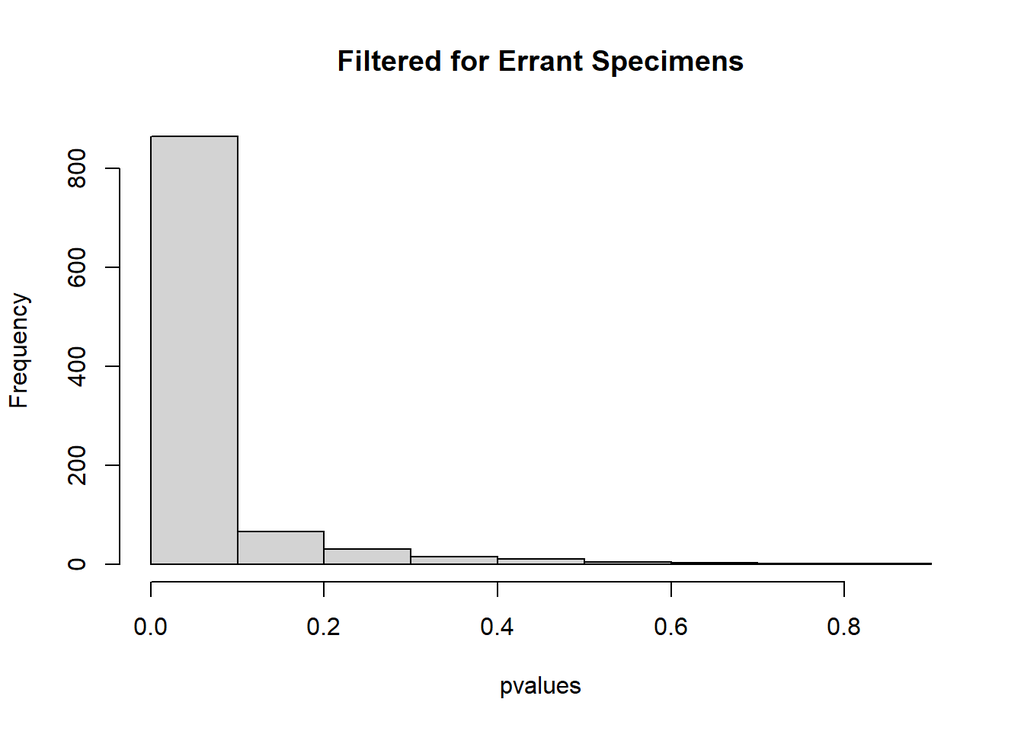

```r
get_p_value_t_test2 <- function() {
  resamp <- hist2 %>% sample_frac(1, replace = TRUE)
  tresults <- t.test(BoneDensity ~ Treatment.Group, data = resamp, var.equal = TRUE)
  return(tresults$p.value)
}
set.seed(123)
pvalues <- replicate(n = 1000, expr=get_p_value_t_test2())
sig3 <- sum(pvalues < 0.05)
hist(pvalues, main="Filtered for Errant Specimens")
```

```r
print(sig3)
```

```
[1] 781
```

```r
pvaluesadj <- p.adjust(pvalues, method = "bonferroni")
sig4 <- sum(pvaluesadj < 0.05)
print(sig4)
```

```
[1] 88
```

To evaluate the statistical significance of differences in bone density between treatments within bone groups, a similar t-test was carried out for each bone group between treatments, for both unfiltered and filtered data, as shown below. As presented, the p-values for all four bone groups are insignificant for unfiltered data. However, in filtered data both distal fin rays (p-value=2.31e-14), and radials (p-value=.0021) showed significant difference between treatment groups.

```r
boneavg <- data %>% group_by(Bone.Group, Treatment.Group) %>% summarise(meandensity=mean(BoneDensity), SDdensity=sd(BoneDensity), count=n())
print(boneavg)
```

```
# A tibble: 8 × 5
# Groups:   Bone.Group [4]
  Bone.Group        Treatment.Group meandensity SDdensity count
  <chr>             <chr>                 <dbl>     <dbl> <int>
1 Distal_Fin_Rays   Aquatic               1579.     1722.   250
2 Distal_Fin_Rays   Terrestrial           1804.     2603.   250
3 Prop_Metap        Aquatic               4393.     4281.    50
4 Prop_Metap        Terrestrial           3866.     5733.    50
5 Proximal_Fin_Rays Aquatic               3653.     3830.   250
6 Proximal_Fin_Rays Terrestrial           3887.     6023.   250
7 Radials           Aquatic               1816.     1948.   330
8 Radials           Terrestrial           2006.     3056.   350
```

```r
ttest1 <- data %>% group_by(Bone.Group) %>% summarise(t_value = t.test(BoneDensity[Treatment.Group == "Aquatic"], BoneDensity[Treatment.Group == "Terrestrial"])$statistic, pvalues= t.test(BoneDensity[Treatment.Group == "Aquatic"], BoneDensity[Treatment.Group == "Terrestrial"])$p.value)
print(ttest1)
```

```
# A tibble: 4 × 3
  Bone.Group        t_value pvalues
  <chr>               <dbl>   <dbl>
1 Distal_Fin_Rays    -1.14    0.255
2 Prop_Metap          0.521   0.604
3 Proximal_Fin_Rays  -0.517   0.605
4 Radials            -0.972   0.331
```

```r
boneavg2 <- filtdata %>% group_by(Bone.Group, Treatment.Group) %>% summarise(meandensity=mean(BoneDensity), SDdensity=sd(BoneDensity), count=n())
print(boneavg2)
```

```
# A tibble: 8 × 5
# Groups:   Bone.Group [4]
  Bone.Group        Treatment.Group meandensity SDdensity count
  <chr>             <chr>                 <dbl>     <dbl> <int>
1 Distal_Fin_Rays   Aquatic                496.     108.    150
2 Distal_Fin_Rays   Terrestrial            666.     272.    200
3 Prop_Metap        Aquatic               1058.      90.9    30
4 Prop_Metap        Terrestrial           1055.     115.     40
5 Proximal_Fin_Rays Aquatic                892.     196.    150
6 Proximal_Fin_Rays Terrestrial            931.     216.    200
7 Radials           Aquatic                634.     157.    205
8 Radials           Terrestrial            589.     161.    285
```

```r
ttest2 <- filtdata %>% group_by(Bone.Group) %>% summarise(t_value = t.test(BoneDensity[Treatment.Group == "Aquatic"], BoneDensity[Treatment.Group == "Terrestrial"])$statistic, pvalues= t.test(BoneDensity[Treatment.Group == "Aquatic"], BoneDensity[Treatment.Group == "Terrestrial"])$p.value)
print(ttest2)
```

```
# A tibble: 4 × 3
  Bone.Group        t_value  pvalues
  <chr>               <dbl>    <dbl>
1 Distal_Fin_Rays    -8.06  2.31e-14
2 Prop_Metap          0.108 9.14e- 1
3 Proximal_Fin_Rays  -1.76  7.94e- 2
4 Radials             3.10  2.09e- 3
```

Similar bootstrapping with re sampling with replacement for each of the bone groups shows similar robustness in un-adjusted histograms, while bonferroni adjustment again shows 0 counts of significant results in unfiltered data, and 40-50/1000 (4-5%) significant results in filtered data. This again suggests some strength in the relationship between treatment groups within specific bone groups, although to a lesser extent than overall across bone groups. Overall these analyses show some points of significant difference in bone density both overall across bone groups and within groups (particularly within distal fin rays and radials), which invite further investigation into these particular comparisons with more data later on.

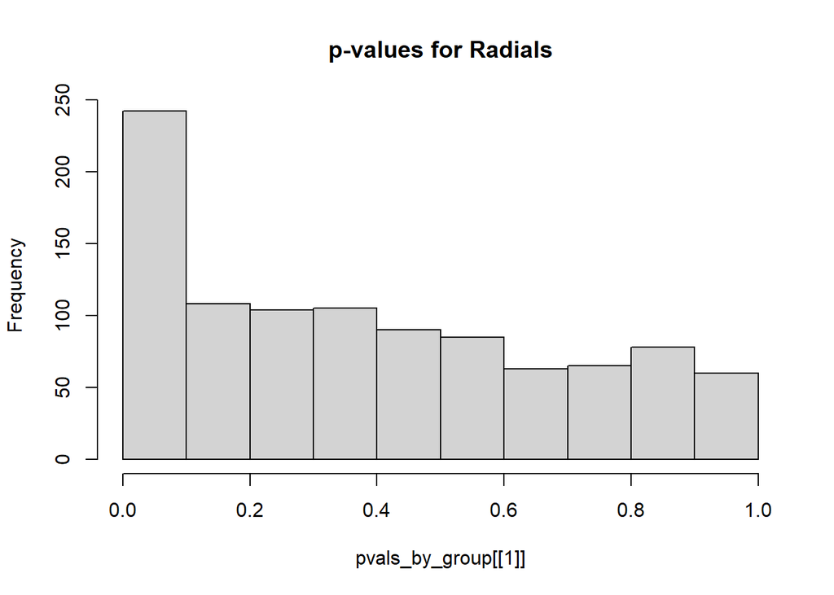

```r
get_p_value_t_test3 <- function(bonegroup) {
  resamp <- hist1 %>% sample_frac(1, replace = TRUE)
  tresults <- t.test(BoneDensity ~ Treatment.Group, data = resamp, var.equal = TRUE)
  return(tresults$p.value)
}
pvals_by_group <- list()
set.seed(123)
for (bone_group in unique(hist1$Bone.Group)) {

  bonegroup <- hist1 %>% filter(Bone.Group == bone_group)
  pvalues <- replicate(n = 1000, expr=get_p_value_t_test3(bonegroup))
  pvals_by_group[[bone_group]] <- pvalues
}

hist(pvals_by_group[[1]], main=paste("p-values for", names(pvals_by_group)[1]))
```

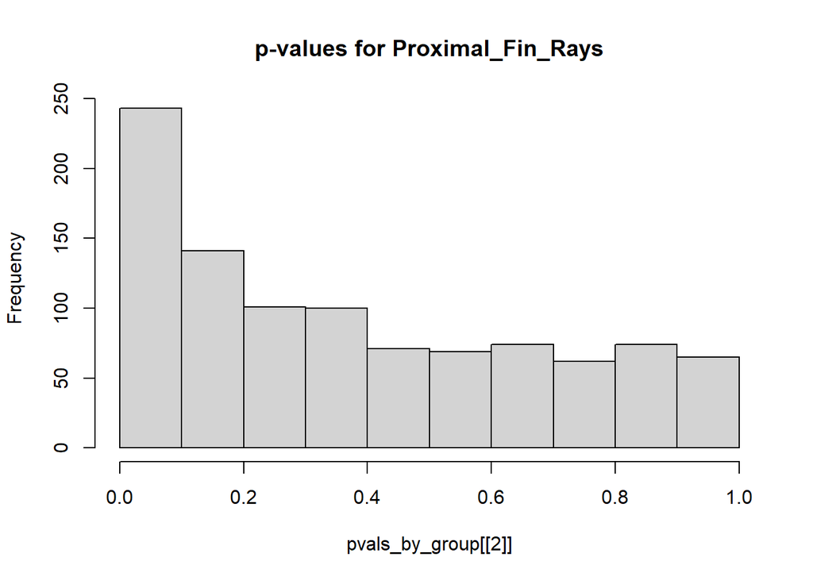

```r
hist(pvals_by_group[[2]], main=paste("p-values for", names(pvals_by_group)[2]))
```

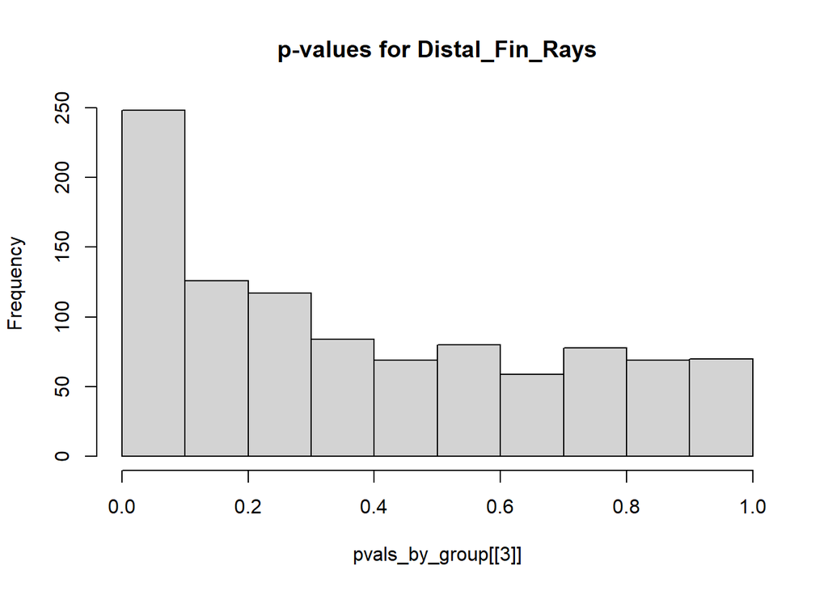

```r
hist(pvals_by_group[[3]], main=paste("p-values for", names(pvals_by_group)[3]))
```

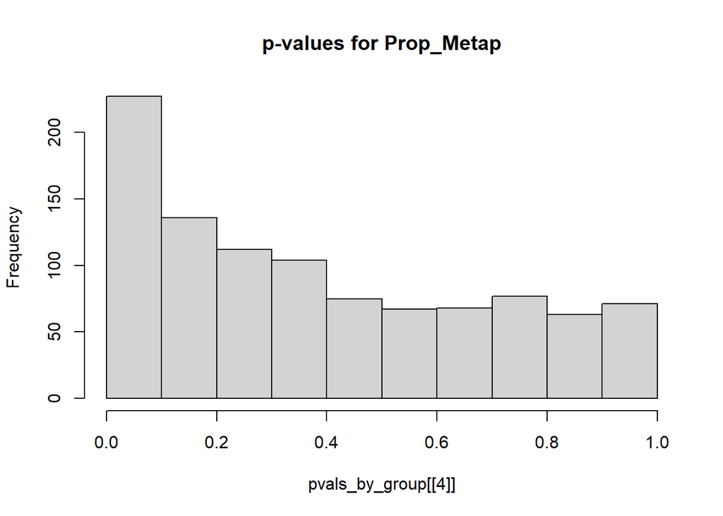

```r
hist(pvals_by_group[[4]], main=paste("p-values for", names(pvals_by_group)[4]))
```

```r
sig2_by_bone_group <- sapply(pvals_by_group, function(pvals) sum(pvals < 0.05))

print(sig2_by_bone_group)
```

```
          Radials Proximal_Fin_Rays   Distal_Fin_Rays        Prop_Metap
              150               166               162               134
```

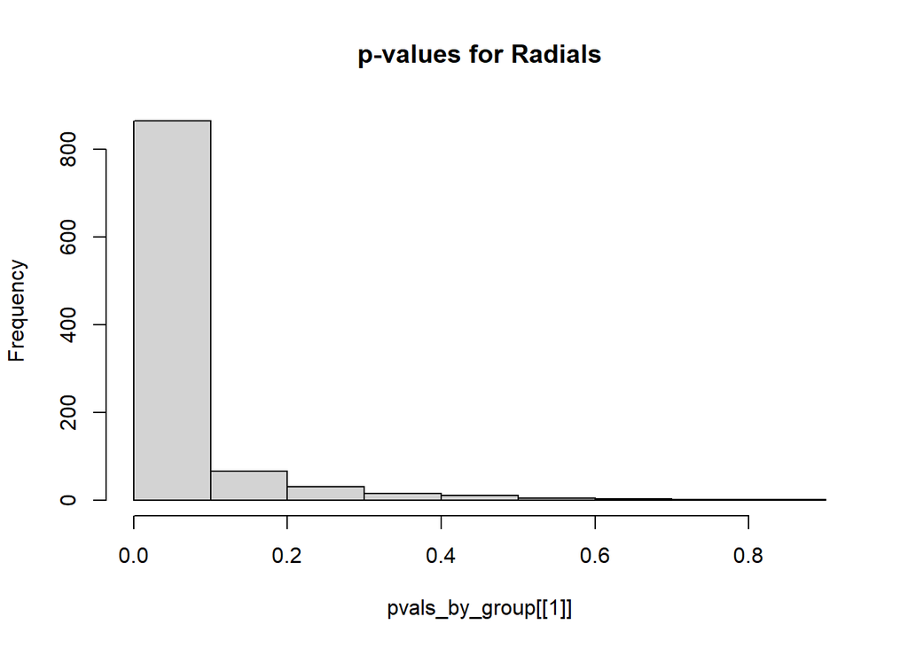

```r
get_p_value_t_test4 <- function(bonegroup) {
  resamp <- hist2 %>% sample_frac(1, replace = TRUE)
  tresults <- t.test(BoneDensity ~ Treatment.Group, data = resamp, var.equal = TRUE)
  return(tresults$p.value)
}
pvals_by_group <- list()
set.seed(123)
for (bone_group in unique(hist2$Bone.Group)) {

  bonegroup <- hist2 %>% filter(Bone.Group == bone_group)
  pvalues <- replicate(n = 1000, expr=get_p_value_t_test4(bonegroup))
  pvals_by_group[[bone_group]] <- pvalues
}

hist(pvals_by_group[[1]], main=paste("p-values for", names(pvals_by_group)[1]))
```

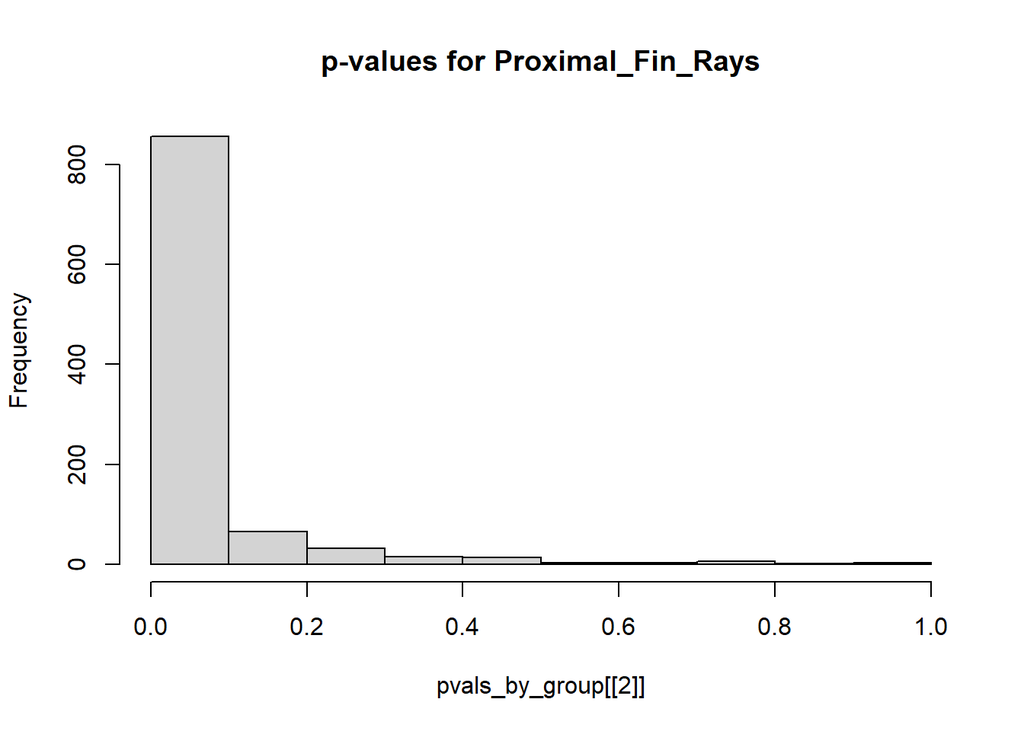

```r
hist(pvals_by_group[[2]], main=paste("p-values for", names(pvals_by_group)[2]))
```

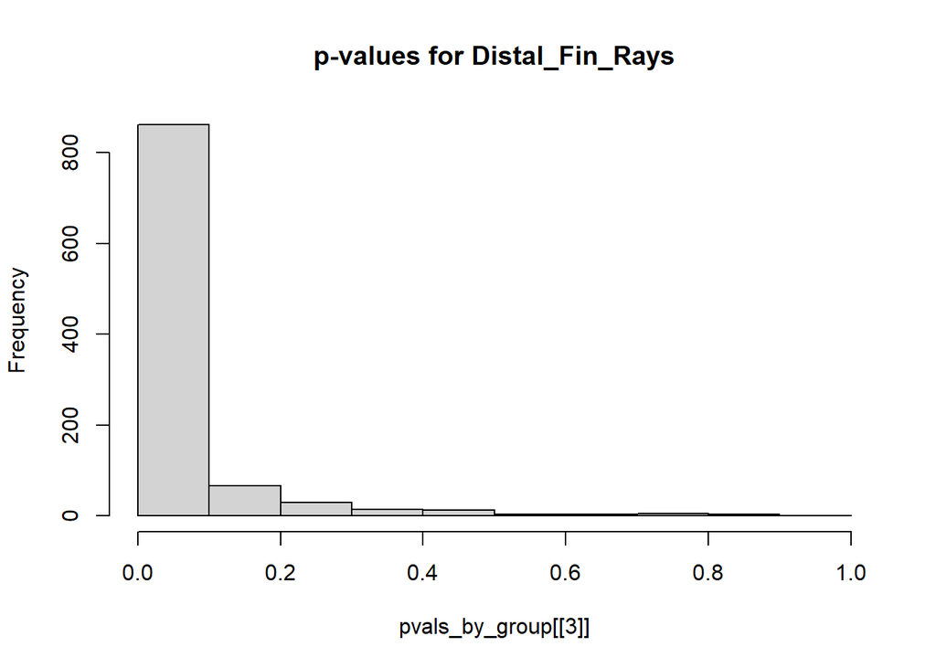

```r
hist(pvals_by_group[[3]], main=paste("p-values for", names(pvals_by_group)[3]))
```

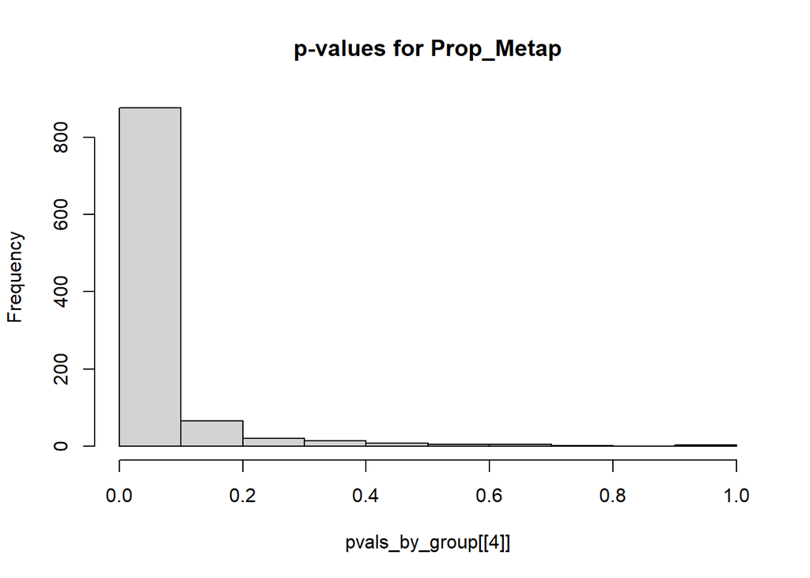

```r
hist(pvals_by_group[[4]], main=paste("p-values for", names(pvals_by_group)[4]))
```

```r
sig2_by_bone_group <- sapply(pvals_by_group, function(pvals) sum(pvals < 0.05))

print(sig2_by_bone_group)
```

```
          Radials Proximal_Fin_Rays   Distal_Fin_Rays        Prop_Metap
              781               765               778               788
```

```r
p_value_t_test3 <- function(bonegroup) {
  resamp <- hist1 %>% sample_frac(1, replace = TRUE)
  tresults <- t.test(BoneDensity ~ Treatment.Group, data = resamp, var.equal = TRUE)
  return(tresults$p.value)
}


pvals_by_group <- list()
set.seed(123)
for (bone_group in unique(hist1$Bone.Group)) {
  bonegroup <- hist1 %>% filter(Bone.Group == bone_group)
  pvalues <- replicate(n = 1000, expr=p_value_t_test3(bonegroup))
  pvals_by_group[[bone_group]] <- pvalues
}


all_pvals <- unlist(pvals_by_group)


adjusted_pvals <- p.adjust(all_pvals, method = "bonferroni")


adjusted_pvals_by_group <- split(adjusted_pvals, rep(1:length(pvals_by_group), times = sapply(pvals_by_group, length)))


sig2_by_bone_group <- sapply(adjusted_pvals_by_group, function(pvals) sum(pvals < 0.05))

print(sig2_by_bone_group)
```

```
1 2 3 4
0 0 0 0
```

```r
p_value_t_test4 <- function(bonegroup) {
  resamp <- hist2 %>% sample_frac(1, replace = TRUE)
  tresults <- t.test(BoneDensity ~ Treatment.Group, data = resamp, var.equal = TRUE)
  return(tresults$p.value)
}


pvals_by_group <- list()
set.seed(123)
for (bone_group in unique(hist2$Bone.Group)) {
  bonegroup <- hist2 %>% filter(Bone.Group == bone_group)
  pvalues <- replicate(n = 1000, expr=p_value_t_test4(bonegroup))
  pvals_by_group[[bone_group]] <- pvalues
}

all_pvals <- unlist(pvals_by_group)

adjusted_pvals <- p.adjust(all_pvals, method = "bonferroni")

adjusted_pvals_by_group <- split(adjusted_pvals, rep(1:length(pvals_by_group), times = sapply(pvals_by_group, length)))

sig2_by_bone_group <- sapply(adjusted_pvals_by_group, function(pvals) sum(pvals < 0.05))

print(sig2_by_bone_group)
```

```
 1  2  3  4
41 46 49 39
```

The second question of this project was, “Is there significant difference in bone density between anterior (ventral) and posterior (dorsal) bone elements (overall and between treatments)?”. The rationale behind this question is that polypterus using their pectoral fins for load support use the anterior (ventral) portion of their fins to interact with the substrate on which they are ‘walking’ is in, and therefore these regions might demonstrate higher bone densities to compensate for this higher physical stress.

To evaluate this question each bone group was separated out, and averaged by individual element with the group. Starting with radials, the first plot shows boxplots for each individually numbered radial across treatments, with radial 1 being most dorsal and radial 15 being most ventral. Filtered data in the second plot seems to begin to show an upward trend in bone density moving from dorsal to ventral positioning. This was tested using a linear regression with first the averages from each individual (R-squared: 0.2306, p-value: 5.613e-7), then condensed to the averages across individuals for each individual radial. The regression for this plot gave an R-squared value of 0.5903 and p-value of 8.2e-4. Next, since only 2 individuals were observed with a 15th radial, this 15th radial was removed to better capture the average fin, shown in the third regression plot (R-squared: 0.9076, p-value: 1.465e-7). Comparing these results to unfiltered data averaged by radial number (R-squared: .2634, p-value: 0.035), it is clear that even without tweaking the data for better trend representation the filtered data assigns much higher explanatory power to radial number (dorsal/ventral positioning) compared to unfiltered data, while regardless there is apparent explanatory power in positioning along this axis for bone density within radials.

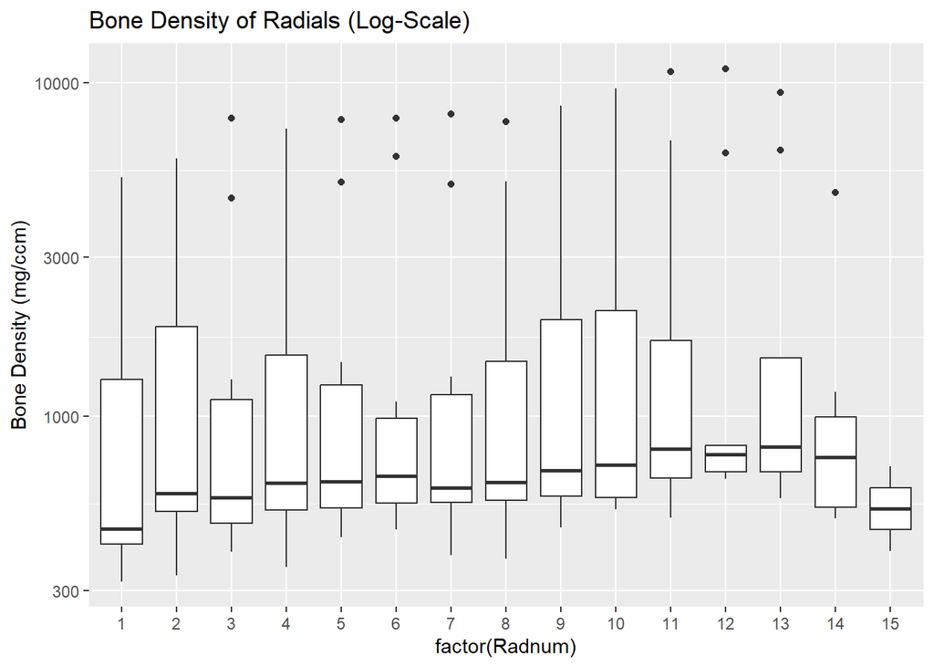

```r
rad1 <- data %>% filter(Bone.Group == "Radials") %>% group_by(Specimen.ID) %>% mutate(Radnum = rep(1:15, each=5, length.out=n())) %>% group_by(Specimen.ID, Radnum) %>% summarise(meanbonedense = mean(BoneDensity, na.rm = TRUE))
ggplot(rad1, aes(x=factor(Radnum), y=meanbonedense)) + geom_boxplot() + labs(title="Bone Density of Radials (Log-Scale)", y="Bone Density (mg/ccm)") + scale_y_log10()
```

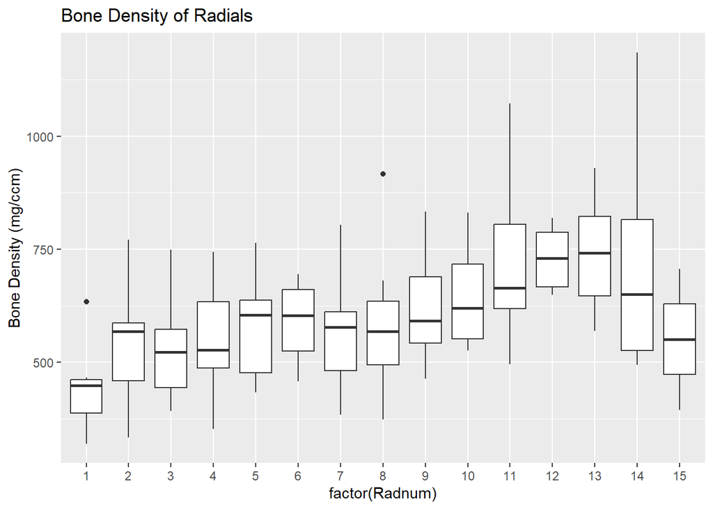

```r
rad2 <- filtdata %>% filter(Bone.Group == "Radials") %>% group_by(Specimen.ID) %>% mutate(Radnum = rep(1:15, each=5, length.out=n())) %>% group_by(Specimen.ID, Radnum) %>% summarise(meanbonedense = mean(BoneDensity, na.rm = TRUE))
ggplot(rad2, aes(x=factor(Radnum), y=meanbonedense)) + geom_boxplot() + labs(title="Bone Density of Radials", y="Bone Density (mg/ccm)")
```

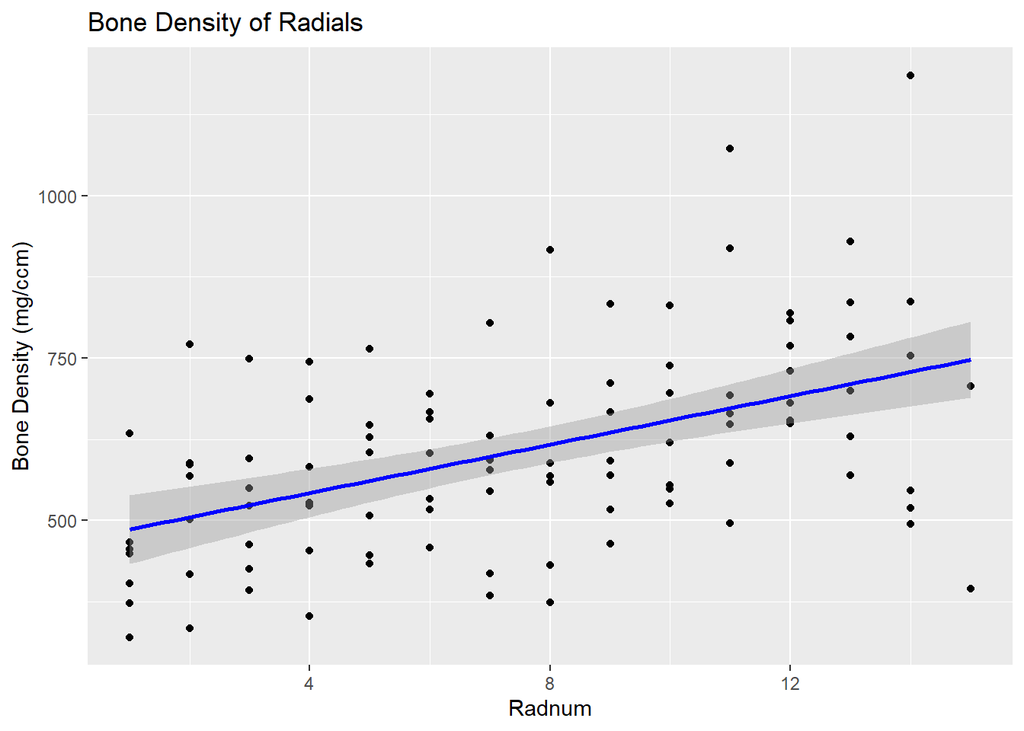

```r
ggplot(rad2, aes(x=Radnum, y=meanbonedense)) + geom_point() + geom_smooth(method="lm", color='blue') + labs(title="Bone Density of Radials", y="Bone Density (mg/ccm)")
```

```r
lmrad <- lm(meanbonedense ~ Radnum, data = rad2)
summary(lmrad)
```

```
Call:
lm(formula = meanbonedense ~ Radnum, data = rad2)

Residuals:
    Min      1Q  Median      3Q     Max
-352.36  -88.90  -17.53   76.95  456.72

Coefficients:
            Estimate Std. Error t value Pr(>|t|)
(Intercept)  467.694     29.792  15.699  < 2e-16 ***
Radnum        18.658      3.478   5.364 5.61e-07 ***
---
Signif. codes:  0 '***' 0.001 '**' 0.01 '*' 0.05 '.' 0.1 ' ' 1

Residual standard error: 140.5 on 96 degrees of freedom
Multiple R-squared:  0.2306,    Adjusted R-squared:  0.2226
F-statistic: 28.78 on 1 and 96 DF,  p-value: 5.613e-07
```